# Classifying cancer variants

> The aim of this is to practice some python, ML and hopefully NLP skills
- The workflow of the notebook:
  1. Data exploration
  2. Feature engineering
  3. Predict variant classification
  4. Evaluate predictions

## Data exploration

```python
import os

import numpy as np
import pandas as pd

# parrallel pandas
from pandarallel import pandarallel

import torch
import transformers as ppb

from sklearn.model_selection import train_test_split
from sklearn.ensemble import RandomForestClassifier
from sklearn.model_selection import GridSearchCV
from sklearn.model_selection import RandomizedSearchCV

from sklearn import metrics

import seaborn as sns
import matplotlib.pyplot as plt

%load_ext autotime
```

```python
os.chdir("/data/kaggling/personalised_med/")

train_var = pd.read_csv("raw_data/msk-redefining-cancer-treatment/training_variants.zip")
train_text = pd.read_csv("raw_data/msk-redefining-cancer-treatment/training_text.zip",
                         skiprows = 1, sep = "\|\|", header = None, names = ["ID", "Text"], engine = 'python')

test_var = pd.read_csv("raw_data/msk-redefining-cancer-treatment/test_variants.zip")
test_text = pd.read_csv("raw_data/msk-redefining-cancer-treatment/test_text.zip",
                        skiprows = 1, sep = "\|\|", header = None, names = ["ID", "Text"], engine = 'python')
```

```
time: 6.99 s
```

```python
# join variant and abstract data
train_df = pd.merge(train_var, train_text)
test_df = pd.merge(test_var, test_text)
```

```
time: 10.8 ms
```

```python
# remove NA abstracts
train_df = train_df[train_df["Text"].notna()].reset_index()
```

```
time: 3.62 ms
```

```python
print(train_df.shape)
test_df.shape
```

```
(3316, 6)
```

```
(5668, 4)
```

```
time: 3.73 ms
```

# Feature engineering

- Let's split this into 2 separate parts, firstly classifying the variant based on the genic information and the secondly, extracting information from the abstract.
  1. Classifying cancergencity of variant.

     ```
      a. Look for existing algorithms that do the job (Take info and gene and variant and predict severity/pathogenicity)
      b. Apply these - VEP/ANNOVAR?
     ```

  2. Mining information from abstracts.

     ```
      a. Simple baseline model: clean text, take the most frequent x number of words then tokenise.
      b. Does the journal have predictive power?
      c. BERT
     ```

## BERT

- BERT (Bidirectional Encoder Representations from Transformers) is a technique that google made that has been pre-trained on a huge amount of text data (corpus) and allows for context dependent encoding of sentences and text.
- A great simple implementation can be found http://jalammar.github.io/a-visual-guide-to-using-bert-for-the-first-time/ / https://github.com/jalammar/jalammar.github.io/blob/master/notebooks/bert/A_Visual_Notebook_to_Using_BERT_for_the_First_Time.ipynb

```python
# For DistilBERT (a smaller, faster younger brother of BERT):
model_class, tokenizer_class, pretrained_weights = (ppb.DistilBertModel, ppb.DistilBertTokenizer, 'distilbert-base-uncased')

## Want BERT instead of distilBERT? Uncomment the following line:
#model_class, tokenizer_class, pretrained_weights = (ppb.BertModel, ppb.BertTokenizer, 'bert-base-uncased')

# Load pretrained model/tokenizer
tokenizer = tokenizer_class.from_pretrained(pretrained_weights)
model = model_class.from_pretrained(pretrained_weights)
```

```
time: 18.4 s
```

- One big issue faced is that BERT currently only operates on small sentences/paragraphs (each only 512 tokens in length).
- This doesn't yet seem to be resolved by the BERT team and looks like it's due to the way BERT's been trained.
- There's some potential solutions here https://stackoverflow.com/questions/58636587/how-to-use-bert-for-long-text-classification / https://github.com/google-research/bert/issues/66
- But for now, let's try by truncating the abstract to it's first 512 tokens.

```python
# tokenise the text
# take 1 minute for tokenising 50 abstracts without parrallelisation
# takes X for tokenising all with parrallelisation over 80 cores
pandarallel.initialize(nb_workers  = 60,
                       progress_bar = False)

tokenised = train_df["Text"].\
parallel_apply(lambda x: tokenizer.encode(x, add_special_tokens = True, max_length = 512))
```

```
INFO: Pandarallel will run on 60 workers.
INFO: Pandarallel will use Memory file system to transfer data between the main process and workers.
time: 5min 36s
```

```python
# has this changed the order? Let's manually check few entries
for i in [0, 100, (len(train_df) - 1)]:

    x = tokenizer.encode(train_df["Text"][i], add_special_tokens = True, max_length = 512)
    y = tokenised[i]

    # can check if 2 lists are equal using "=="
    print(x == y)
```

```
True
True
True
time: 12.8 s
```

```python
# now each abstract is a vector with each word/punc encoded into a token
print(tokenised.shape)
tokenised[1:5]
```

```
(3316,)
```

```
1    [101, 10061, 4281, 2512, 1011, 2235, 3526, 111...
2    [101, 10061, 4281, 2512, 1011, 2235, 3526, 111...
3    [101, 3522, 3350, 2038, 7645, 2008, 3734, 4895...
4    [101, 2006, 3597, 16505, 14494, 1999, 1996, 18...
Name: Text, dtype: object
```

```
time: 7.24 ms
```

```python
# pad up the tokens into a 2d matrix ready for input into tensor
# padding means to add 0s to the end of each vector so they're all the same length
max_len = 0
for i in tokenised.values:
    if len(i) > max_len:
        max_len = len(i)

# beautiful list comphehension for adding 0's up to the max length
padded = np.array([i + [0]*(max_len-len(i)) for i in tokenised.values])

print(padded.shape)
padded[0:5]
```

```
(3316, 512)
```

```
array([[  101, 22330, 20464, ...,  2070,  4442,   102],
       [  101, 10061,  4281, ...,  1012,  2004,   102],
       [  101, 10061,  4281, ...,  1012,  2004,   102],
       [  101,  3522,  3350, ...,  2029,  2265,   102],
       [  101,  2006,  3597, ...,  2024,  7356,   102]])
```

```
time: 203 ms
```

```python
# then we have to tell BERT to ignore the areas in which we've padded
attention_mask = np.where(padded != 0, 1, 0)
attention_mask[0:5]
```

```
array([[1, 1, 1, ..., 1, 1, 1],
       [1, 1, 1, ..., 1, 1, 1],
       [1, 1, 1, ..., 1, 1, 1],
       [1, 1, 1, ..., 1, 1, 1],
       [1, 1, 1, ..., 1, 1, 1]])
```

```
time: 10.4 ms
```

```python
# apparantly these functions construct a tensor - no idea, read up later
# looks much quicker on server than my local, internal multithreading??
input_ids = torch.tensor(padded)
attention_mask = torch.tensor(attention_mask)

with torch.no_grad():
    last_hidden_states = model(input_ids, attention_mask = attention_mask)
```

```
time: 7min 25s
```

```python
# extract the feature we actually need...
# last_hidden_states is some 3d tuble, we basically want the first col
features = last_hidden_states[0][:,0,:].numpy()
features = pd.DataFrame(features,
                        columns = ["X" + str(i) for i in range(features.shape[1])])

print(features.shape)
features.iloc[range(5)]
```

```
(3316, 768)
```

|  | X0 | X1 | X2 | X3 | X4 | X5 | X6 | X7 | X8 | X9 | ... | X758 | X759 | X760 | X761 | X762 | X763 | X764 | X765 | X766 | X767 |
| --- | --- | --- | --- | --- | --- | --- | --- | --- | --- | --- | --- | --- | --- | --- | --- | --- | --- | --- | --- | --- | --- |
| 0 | -0.357481 | -0.017413 | -0.159776 | -0.092079 | 0.096843 | -0.220848 | 0.316619 | -0.217302 | -0.070082 | -0.106983 | ... | 0.176891 | -0.149806 | -0.203046 | 0.020054 | 0.018851 | 0.041817 | -0.059973 | -0.111114 | 0.350028 | 0.428829 |
| 1 | -0.444488 | -0.153175 | -0.356332 | -0.072857 | 0.126543 | 0.060627 | 0.084730 | -0.122758 | -0.094950 | -0.253415 | ... | 0.080443 | -0.110614 | -0.081563 | -0.023074 | -0.093389 | 0.148436 | -0.160686 | -0.218967 | 0.379110 | 0.542377 |
| 2 | -0.444488 | -0.153175 | -0.356332 | -0.072857 | 0.126543 | 0.060627 | 0.084730 | -0.122758 | -0.094950 | -0.253415 | ... | 0.080443 | -0.110614 | -0.081563 | -0.023074 | -0.093389 | 0.148436 | -0.160686 | -0.218967 | 0.379110 | 0.542377 |
| 3 | -0.332727 | -0.146111 | -0.344226 | -0.042260 | 0.342653 | -0.000134 | 0.315199 | -0.176562 | 0.016619 | -0.137244 | ... | -0.005574 | -0.060333 | -0.152024 | -0.100370 | -0.093741 | 0.026119 | -0.231168 | -0.185014 | 0.392335 | 0.417319 |
| 4 | -0.399492 | -0.079763 | -0.396400 | -0.042757 | 0.273814 | -0.035057 | 0.286812 | -0.238444 | 0.021866 | -0.242645 | ... | 0.106880 | -0.131835 | -0.105780 | -0.108750 | -0.119301 | -0.002419 | -0.116512 | -0.274350 | 0.443917 | 0.457941 |

5 rows × 768 columns

```
time: 64.6 ms
```

```python
train_df_tidy = pd.concat([train_df[["Class"]], features], axis = 1)
train_df_tidy.head()

train_df_tidy.to_csv("/home/dzhang/misc_projects/kaggling/personalised_med/results/train_df_BERT_encoded.csv")
```

```
time: 3.68 s
```

# Predict variant classification

```python
train, valid = train_test_split(train_df_tidy, # DataFrame to split
                                test_size = 0.2, # proportion to split
                                random_state = 32)
print(train.shape)
print(valid.shape)
```

```
(2652, 769)
(664, 769)
time: 18.3 ms
```

```python
rf = RandomForestClassifier(n_jobs = 30, random_state = 32)

# CV hyperparameter tune
rf = GridSearchCV(estimator = rf,
                  param_grid = {'n_estimators': [100, 250],
                                'max_features': ["auto"],
                                'max_depth': [10, 25, 100],
                                'min_samples_split': [2, 5, 10],
                                'min_samples_leaf': [1, 2, 4]},
                          cv = 5,
                          n_jobs = 30)

rf.fit(X = train.drop(["Class"], axis = 1),
       y = train["Class"])
```

```
GridSearchCV(cv=5, error_score='raise-deprecating',
             estimator=RandomForestClassifier(bootstrap=True, class_weight=None,
                                              criterion='gini', max_depth=None,
                                              max_features='auto',
                                              max_leaf_nodes=None,
                                              min_impurity_decrease=0.0,
                                              min_impurity_split=None,
                                              min_samples_leaf=1,
                                              min_samples_split=2,
                                              min_weight_fraction_leaf=0.0,
                                              n_estimators='warn', n_jobs=30,
                                              oob_score=False, random_state=32,
                                              verbose=0, warm_start=False),
             iid='warn', n_jobs=30,
             param_grid={'max_depth': [10, 25, 100], 'max_features': ['auto'],
                         'min_samples_leaf': [1, 2, 4],
                         'min_samples_split': [2, 5, 10],
                         'n_estimators': [100, 250]},
             pre_dispatch='2*n_jobs', refit=True, return_train_score=False,
             scoring=None, verbose=0)
```

```
time: 36.3 s
```

```python
# get preds
preds = rf.predict(valid.drop(["Class"], axis = 1))
preds_proba = rf.predict_proba(valid.drop(["Class"], axis = 1))
```

```
time: 246 ms
```

# Evaluate predictions

```python
print(metrics.accuracy_score(valid["Class"], preds))
print(metrics.log_loss(valid["Class"], preds_proba))
```

```
0.5135542168674698
1.3407119520625645
time: 9.4 ms
```

```
Confusion matrix, without normalization
[[ 42   3   0  18  14   5  33   0   0]
 [  3  28   0   2   0   2  66   0   0]
 [  1   0   0   3   2   0  12   0   0]
 [ 27   1   0  71   5   3  25   0   0]
 [ 12   2   1  10  12   2  15   0   0]
 [  7   1   0   0   4  24  15   0   0]
 [  3  18   0   1   2   0 160   0   0]
 [  0   0   0   0   0   0   1   0   0]
 [  0   0   0   3   0   0   1   0   4]]
```

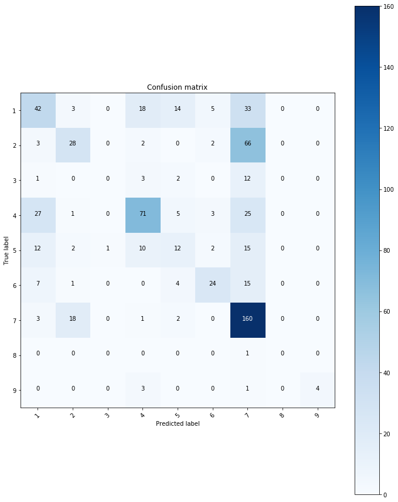

```
time: 876 ms
```

```python
def plot_confusion_matrix(cm, classes,
                          normalize=False,
                          title='Confusion matrix',
                          cmap=plt.cm.Blues):
    """
    This function prints and plots the confusion matrix.
    Normalization can be applied by setting `normalize=True`.
    """
    import itertools
    if normalize:
        cm = cm.astype('float') / cm.sum(axis=1)[:, np.newaxis]
        print("Normalized confusion matrix")
    else:
        print('Confusion matrix, without normalization')

    print(cm)

    plt.imshow(cm, interpolation='nearest', cmap=cmap)
    plt.title(title)
    plt.colorbar()
    tick_marks = np.arange(len(classes))
    plt.xticks(tick_marks, classes, rotation=45)
    plt.yticks(tick_marks, classes)

    fmt = '.2f' if normalize else 'd'
    thresh = cm.max() / 2.
    for i, j in itertools.product(range(cm.shape[0]), range(cm.shape[1])):
        plt.text(j, i, format(cm[i, j], fmt),
                 horizontalalignment="center",
                 color="white" if cm[i, j] > thresh else "black")

    plt.ylabel('True label')
    plt.xlabel('Predicted label')
    plt.tight_layout()

cfm = metrics.confusion_matrix(valid["Class"], preds,
                               labels = [x for x in sorted(valid["Class"].unique())])
plt.figure(figsize=(10, 12))
plot_confusion_matrix(cfm, classes = [x for x in sorted(valid["Class"].unique())],
                      title = 'Confusion matrix')
```

```python
#/usr/local/bin/jupyter nbconvert --to html \
#--ExecutePreprocessor.timeout=1000000000 \ # force timeout to be very long
#--execute ~/misc_projects/kaggling/personalised_med/scripts/personalised_med_kaggle.ipynb
```

```
time: 468 µs
```